# Demo: From Observed Treasury Yields to Hull–White Future Curves

## 1 Goal

This demo follows one complete fixed-income workflow:

1. start with a **dated U.S. Treasury par-yield snapshot**;
2. bootstrap today’s discount factors and zero-coupon yield curve;
3. calibrate Hull–White so that it exactly respects that curve;
4. fit the model’s mean reversion and volatility to a supplied synthetic option quote snapshot that demonstrates the calibration mechanics;
5. generate yield curves at a future date in different interest-rate states; and
6. use those future curves to price remaining bond cash flows.

The initial curve uses the U.S. Treasury’s published **January 2, 2025** par-yield snapshot. Treasury par yields are bond-equivalent quoted rates; bootstrapped zero rates are continuously compounded. The option premiums used later are synthetic.

Source: [U.S. Treasury, Daily Treasury Par Yield Curve Rates](https://home.treasury.gov/resource-center/data-chart-center/interest-rates/TextView?type=daily_treasury_yield_curve&field_tdr_date_value=2025).

**TipThe central idea**

Today’s curve determines today’s prices. Hull–White adds a disciplined way to describe *future* curves. Calibration makes those two statements consistent.

## 2 Setup

### 2.1 Read the workflow in two layers

**Valuation today:** dated Treasury par yields → constructed annual-pay par coupon bonds → bootstrapped discount factors → present value of fixed cash flows. These constructed instruments are a curve-building convention, not individual Treasury securities or their actual coupons.

**Uncertainty tomorrow:** supplied synthetic option premiums → fitted mean reversion $a$ and volatility $\sigma$ → curve-consistent drift $\theta(t)$ → future short-rate state $r_t$ → future discount curve → remaining bond value. The premiums illustrate calibration; they are not observed option quotes. The second layer must preserve the first. A complicated model is not allowed to change today’s price of fixed cash flows once the discount curve is fixed.

Open **Show calculation** to inspect each step. The final explorer lets you change the input curve, model parameters, and future short-rate state.

**Show calculation**

```python
import math
import numpy as np
import pandas as pd
import matplotlib.pyplot as plt

from IPython.display import display

np.random.seed(411)

# A restrained, consistent plotting style.
BLUE = "#214b3e"
GOLD = "#936724"
INK = "#263238"
LIGHT_BLUE = "#b7c7b4"
GRID = "#D9E1E8"

plt.rcParams.update({
    "figure.figsize": (8, 4.6),
    "axes.spines.top": False,
    "axes.spines.right": False,
    "axes.grid": True,
    "grid.alpha": 0.65,
    "grid.color": GRID,
    "axes.titleweight": "bold",
})
```

## 3 Record the observed Treasury curve

The published Treasury series contains par yields at standard maturity nodes. We retain the 1-, 2-, 3-, 5-, 7-, and 10-year observations and linearly interpolate missing integer maturities. The interpolation is an **estimated curve-construction choice**, not an additional market quote. For transparent annual bootstrapping we treat each interpolated par yield as the coupon on an annual-pay par bond. A production Treasury curve would instead use security-level prices, semiannual coupons, actual day counts, accrued interest, and bills at the short end.

**Show calculation**

```python
def price_annual_coupon_bond(coupon_rate, maturity, discount_factors, face=100.0):
    """Price an annual-pay bond from discount factors at integer years.

    discount_factors[k - 1] must equal P(0, k).
    """
    coupon = face * coupon_rate
    cash_flows = np.full(maturity, coupon)
    cash_flows[-1] += face
    return float(np.sum(cash_flows * discount_factors[:maturity]))


observed_date = "2025-01-02"
observed_maturities = np.array([1, 2, 3, 5, 7, 10], dtype=float)
observed_par_yields = np.array([4.17, 4.25, 4.29, 4.38, 4.47, 4.57]) / 100

market_nodes = pd.DataFrame({
    "observation_date": observed_date,
    "maturity_years": observed_maturities,
    "observed_par_yield_pct": 100 * observed_par_yields,
})


maturities = np.arange(1, 11)
coupon_rates = np.interp(maturities, observed_maturities, observed_par_yields)

# Under the annual-pay par-bond convention, a par-yield quote implies price 100.
clean_prices = np.full(len(maturities), 100.0)

bond_market = pd.DataFrame({
    "maturity_years": maturities,
    "par_yield_pct": 100 * coupon_rates,
    "implied_par_price": clean_prices,
    "input_status": np.where(np.isin(maturities, observed_maturities),
                             "Observed Treasury node", "Interpolated node"),
})

market_table = bond_market.copy()
market_table.insert(0, "observation_date", observed_date)
market_table.insert(2, "observed_par_yield_pct", [
    100 * observed_par_yields[np.where(observed_maturities == t)[0][0]]
    if t in observed_maturities else np.nan for t in maturities
])
display(market_table)
```

| Observation date | Maturity (years) | Observed Treasury par yield (%) | Annual par coupon rate (%) | Constructed price per 100 | Input status |
| --- | --- | --- | --- | --- | --- |
| 2025-01-02 | 1 | 4.17 | 4.17 | 100 | Observed Treasury node |
| 2025-01-02 | 2 | 4.25 | 4.25 | 100 | Observed Treasury node |
| 2025-01-02 | 3 | 4.29 | 4.29 | 100 | Observed Treasury node |
| 2025-01-02 | 4 |  | 4.335 | 100 | Interpolated node |
| 2025-01-02 | 5 | 4.38 | 4.38 | 100 | Observed Treasury node |
| 2025-01-02 | 6 |  | 4.425 | 100 | Interpolated node |
| 2025-01-02 | 7 | 4.47 | 4.47 | 100 | Observed Treasury node |
| 2025-01-02 | 8 |  | 4.503333 | 100 | Interpolated node |
| 2025-01-02 | 9 |  | 4.536667 | 100 | Interpolated node |
| 2025-01-02 | 10 | 4.57 | 4.57 | 100 | Observed Treasury node |

Observed nodes are facts from the dated snapshot. Interpolated nodes and the annual-pay par-bond representation are assumptions. That separation matters: a curve can fit its inputs perfectly while still depending on construction choices.

## 4 Bootstrap today’s discount curve

For the one-year bond, the only cash flow is coupon plus principal, so its price immediately gives $P(0,1)$. For each later bond, discount factors for earlier coupons are already known. The final discount factor is the only unknown:

$$P(0,n)=\frac{100-\sum_{i=1}^{n-1}C_nP(0,i)}{100+C_n},
\qquad C_n=100c_n.$$

**Show calculation**

```python
def bootstrap_discount_factors(maturities, coupon_rates, bond_prices, face=100.0):
    """Bootstrap annual discount factors from annual-pay coupon bonds.

    Inputs
    ------
    maturities : array-like of integers
        Consecutive maturities 1, 2, ..., N.
    coupon_rates : array-like
        Annual coupon rates in decimal form.
    bond_prices : array-like
        Constructed par-bond prices per 100 of face value.

    Output
    ------
    NumPy array
        Discount factors P(0, 1), ..., P(0, N).
    """
    maturities = np.asarray(maturities, dtype=int)
    coupon_rates = np.asarray(coupon_rates, dtype=float)
    bond_prices = np.asarray(bond_prices, dtype=float)

    expected = np.arange(1, len(maturities) + 1)
    if not np.array_equal(maturities, expected):
        raise ValueError("Maturities must be consecutive integers starting at 1.")

    discount_factors = np.empty(len(maturities))

    for row, maturity in enumerate(maturities):
        coupon = face * coupon_rates[row]

        # Present value of coupons before the maturity date.
        earlier_coupon_pv = coupon * discount_factors[:row].sum()

        # Solve the bond-pricing equation for the one remaining unknown.
        discount_factors[row] = (
            bond_prices[row] - earlier_coupon_pv
        ) / (face + coupon)

    return discount_factors


bootstrapped_discounts = bootstrap_discount_factors(
    maturities,
    coupon_rates,
    clean_prices,
)
bootstrapped_zero_rates = -np.log(bootstrapped_discounts) / maturities

curve_table = pd.DataFrame({
    "maturity_years": maturities,
    "discount_factor": bootstrapped_discounts,
    "zero_rate_pct": 100 * bootstrapped_zero_rates,
})
display(curve_table.round(6))
```

| Maturity (years) | Discount factor P(0,T) | Continuous zero rate (%) |
| --- | --- | --- |
| 1 | 0.959969 | 4.085399 |
| 2 | 0.920097 | 4.163799 |
| 3 | 0.881528 | 4.203298 |
| 4 | 0.84371 | 4.248659 |
| 5 | 0.806752 | 4.294781 |
| 6 | 0.770665 | 4.3417 |
| 7 | 0.735457 | 4.389466 |
| 8 | 0.701877 | 4.424966 |
| 9 | 0.669306 | 4.461266 |
| 10 | 0.637732 | 4.498374 |

**Show calculation**

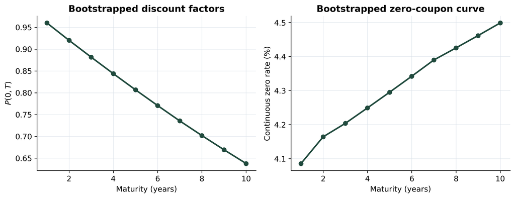

Figure 1: Today’s curve recovered from constructed par coupon bonds

```python
fig, axes = plt.subplots(1, 2, figsize=(10.5, 4.1))

axes[0].plot(maturities, bootstrapped_discounts, "o-", color=BLUE)
axes[0].set(title="Bootstrapped discount factors",
            xlabel="Maturity (years)", ylabel="$P(0,T)$")

axes[1].plot(maturities, 100 * bootstrapped_zero_rates, "o-", color=BLUE)
axes[1].set(title="Bootstrapped zero-coupon curve",
            xlabel="Maturity (years)", ylabel="Continuous zero rate (%)")

plt.tight_layout()
plt.show()
```

### 4.1 Check the bootstrap by repricing every input bond

A useful calibration habit is to return to the original observable quantities.

**Show calculation**

```python
repriced_bonds = np.array([
    price_annual_coupon_bond(coupon, int(maturity), bootstrapped_discounts)
    for coupon, maturity in zip(coupon_rates, maturities)
])

bootstrap_check = bond_market.copy()
bootstrap_check["repriced_from_curve"] = repriced_bonds
bootstrap_check["pricing_error"] = repriced_bonds - clean_prices
display(bootstrap_check.round(8))

print(f"Largest absolute repricing error: "
      f"{np.max(np.abs(repriced_bonds - clean_prices)):.10f} per 100 face")
```

| Maturity (years) | Annual par coupon rate (%) | Constructed price per 100 | Input status | Repriced per 100 | Pricing error per 100 |
| --- | --- | --- | --- | --- | --- |
| 1 | 4.17 | 100 | Observed Treasury node | 100 | 0 |
| 2 | 4.25 | 100 | Observed Treasury node | 100 | 0 |
| 3 | 4.29 | 100 | Observed Treasury node | 100 | 0 |
| 4 | 4.335 | 100 | Interpolated node | 100 | 0 |
| 5 | 4.38 | 100 | Observed Treasury node | 100 | 0 |
| 6 | 4.425 | 100 | Interpolated node | 100 | 0 |
| 7 | 4.47 | 100 | Observed Treasury node | 100 | 0 |
| 8 | 4.503333 | 100 | Interpolated node | 100 | 0 |
| 9 | 4.536667 | 100 | Interpolated node | 100 | 0 |
| 10 | 4.57 | 100 | Observed Treasury node | 100 | 0 |

```
Largest absolute repricing error: 0.0000000000 per 100 face
```

## 5 Fit the Hull–White dynamics to option prices

The lecture’s calibration logic separates two jobs:

- the piecewise-constant function $\theta(t)$ fits every bootstrapped discount target; and
- $a$ and $\sigma$ control future mean reversion and volatility.

In practice, $a$ and $\sigma$ are fitted to liquid caps, floors, or swaptions. To keep the code transparent, our artificial option market consists of European calls on zero-coupon bonds. These option premiums could be observed in a suitable market dataset; the premiums below are synthetic. Hull–White has a closed-form pricing formula for them.

### 5.1 Hull–White building blocks

For the one-factor model

$$dr_t=[\theta(t)-a r_t]dt+\sigma dW_t^{\mathbb Q},$$

$t$ is the valuation time and $T>t$ is a payment maturity, both measured in years. $r_t$ is the instantaneous short rate; $a$ is mean reversion (per year), $\sigma$ is short-rate volatility (per square root of a year), and $\theta(t)$ is the time-dependent drift intercept. $W_t^{\mathbb Q}$ is Brownian motion under the risk-neutral pricing measure. Lowercase $a$ is a scalar parameter; uppercase $A(t,T)$ below is a bond-pricing coefficient, not that parameter.

The zero-coupon bond price is

$$P(t,T)=A(t,T)e^{-B(t,T)r_t},\qquad
B(t,T)=\frac{1-e^{-a(T-t)}}{a}.$$

For the piecewise-constant drift used here,

$$A(t,T)=\exp\!\left[-\int_t^T\theta(u)B(u,T)\,du
+\frac{\sigma^2}{2}\int_t^T B(u,T)^2\,du\right].$$

Capital $A(t,T)$ incorporates the fitted drift and volatility; lowercase $a$ controls mean reversion. The calculation evaluates the interval integrals directly. Given $r_t$ and the fitted model, this gives the price of one unit paid at $T$.

Write the model option premium compactly as

$$C^{\mathrm{model}}(S,T,K; a,\sigma,\boldsymbol\theta(a,\sigma),r_0).$$

$S$ is the option expiry, $T>S$ is the underlying zero-coupon bond’s maturity, and $K$ is the strike paid at expiry. The underlying principal and option premium are quoted per 100 of face value. For each candidate $(a,\sigma)$, the vector $\boldsymbol\theta(a,\sigma)$ is refitted to the bootstrap discount targets. The starting state is fixed at $r_0=-\log P^{\mathrm{boot}}(0,T_1)/T_1$, a convention rather than a separate overnight-rate observation.

**Show calculation**

```python
from functools import lru_cache

curve_times = np.asarray(maturities, dtype=float)
interval_starts = np.r_[0.0, curve_times[:-1]]
interval_ends = np.r_[curve_times[:-1], np.inf]
r_0 = float(bootstrapped_zero_rates[0])


def hw_B(start, end, mean_reversion):
    """Maturity loading for dr=(theta(t)-a*r)dt+sigma*dW."""
    return -np.expm1(-mean_reversion * (np.asarray(end) - start)) / mean_reversion


def interval_weights(start, end, mean_reversion, kind="integral"):
    """Exact theta weights for an integrated rate or an ending short rate.

    The last theta value extends beyond the final bootstrap maturity.
    """
    end = np.asarray(end, dtype=float)
    if np.any(end < start) or start < 0 or mean_reversion <= 0:
        raise ValueError("Require 0 <= start <= end and a > 0.")
    lower = np.maximum(start, interval_starts)
    upper = np.maximum(lower, np.minimum(end[..., None], interval_ends))
    width = upper - lower
    exponential_weight = (
        np.exp(-mean_reversion * (end[..., None] - upper))
        * -np.expm1(-mean_reversion * width) / mean_reversion
    )
    if kind == "state":
        return exponential_weight
    return (width - exponential_weight) / mean_reversion


def integrated_rate_variance(start, end, mean_reversion, volatility):
    """Conditional variance of the Gaussian integral of the short rate."""
    delta = np.asarray(end, dtype=float) - start
    a = mean_reversion
    variance = volatility**2 / a**2 * (
        delta - 2 * hw_B(0.0, delta, a)
        + -np.expm1(-2 * a * delta) / (2 * a)
    )
    return np.maximum(variance, 0.0)


@lru_cache(maxsize=None)
def bootstrap_weights(mean_reversion):
    return interval_weights(0.0, curve_times, mean_reversion)


@lru_cache(maxsize=None)
def fitted_theta(mean_reversion, volatility):
    """Sequentially solve log-discount equations at all bootstrap targets."""
    weights = bootstrap_weights(mean_reversion)
    rhs = (-np.log(bootstrapped_discounts)
           - hw_B(0.0, curve_times, mean_reversion) * r_0
           + 0.5 * integrated_rate_variance(
               0.0, curve_times, mean_reversion, volatility))
    values = np.empty(len(curve_times))
    for i in range(len(values)):
        values[i] = (rhs[i] - weights[i, :i] @ values[:i]) / weights[i, i]
    return values


def hw_discount_factor(valuation_time, maturity, short_rate,
                       mean_reversion, volatility):
    """Conditional ZCB price from the same piecewise-constant theta model."""
    theta_values = fitted_theta(mean_reversion, volatility)
    drift_integral = interval_weights(
        valuation_time, maturity, mean_reversion) @ theta_values
    variance = integrated_rate_variance(
        valuation_time, maturity, mean_reversion, volatility)
    return np.exp(-hw_B(valuation_time, maturity, mean_reversion) * short_rate
                  - drift_integral + 0.5 * variance)


def discount_0(maturity, mean_reversion, volatility):
    """Initial model discount curve; exact at the bootstrap nodes."""
    return hw_discount_factor(0.0, maturity, r_0, mean_reversion, volatility)


def mean_short_rate(start, end, short_rate, mean_reversion, volatility):
    """Exact conditional mean, including every crossed theta interval."""
    return (np.exp(-mean_reversion * (np.asarray(end) - start)) * short_rate
            + interval_weights(start, end, mean_reversion, kind="state")
            @ fitted_theta(mean_reversion, volatility))
```

**Show calculation**

```python
def normal_cdf(x):
    """Standard normal cumulative probability; works for scalars."""
    return 0.5 * (1.0 + math.erf(x / math.sqrt(2.0)))


def zero_bond_call_price(expiry, bond_maturity, strike,
                         mean_reversion, volatility, face=100.0):
    """Price a European call on a zero-coupon bond under Hull–White.

    The option expires at `expiry`. Its underlying pays `face` at
    `bond_maturity`. The strike is paid at expiry per `face` of principal.
    """
    p_0_s = float(discount_0(expiry, mean_reversion, volatility))
    p_0_t = float(discount_0(bond_maturity, mean_reversion, volatility))

    bond_vol = (
        volatility
        * hw_B(expiry, bond_maturity, mean_reversion)
        * math.sqrt((1.0 - math.exp(-2.0 * mean_reversion * expiry))
                    / (2.0 * mean_reversion))
    )

    # Work with values per $1 face, then multiply by face at the end.
    strike_per_dollar = strike / face
    h = (
        math.log(p_0_t / (strike_per_dollar * p_0_s)) / bond_vol
        + 0.5 * bond_vol
    )
    call_per_dollar = (
        p_0_t * normal_cdf(h)
        - strike_per_dollar * p_0_s * normal_cdf(h - bond_vol)
    )
    return face * call_per_dollar
```

### 5.2 Create a synthetic option quote snapshot

We create at-the-money-forward calls with expiries from six months to five years. The hidden values $a=0.18$ per year and $\sigma=1.20\%$ per square root of a year are used only to generate the synthetic premiums. A small alternating bid/ask-like perturbation prevents a mechanically perfect parameter recovery.

**Show calculation**

```python
option_expiries = np.array([0.5, 1.0, 1.5, 2.0, 3.0, 4.0, 5.0])
underlying_maturities = option_expiries + 5.0

# An ATM-forward strike makes the option comparison especially clear.
hidden_a = 0.18
hidden_sigma = 0.012
option_strikes = np.array([
    100.0 * discount_0(maturity, hidden_a, hidden_sigma)
    / discount_0(expiry, hidden_a, hidden_sigma)
    for expiry, maturity in zip(option_expiries, underlying_maturities)
])

quote_perturbation = np.array([1.003, 0.998, 1.002, 0.997, 1.001, 0.999, 1.002])

observed_option_prices = np.array([
    zero_bond_call_price(expiry, maturity, strike, hidden_a, hidden_sigma)
    for expiry, maturity, strike in zip(
        option_expiries, underlying_maturities, option_strikes
    )
]) * quote_perturbation

option_market = pd.DataFrame({
    "option_expiry": option_expiries,
    "bond_maturity": underlying_maturities,
    "strike_per_100": option_strikes,
    "observed_option_price": observed_option_prices,
})
display(option_market.round(5))
```

| Option expiry (years) | Bond maturity (years) | Strike per 100 | Synthetic option premium per 100 |
| --- | --- | --- | --- |
| 0.5 | 5.5 | 80.51466 | 0.84472 |
| 1 | 6 | 80.28013 | 1.11236 |
| 1.5 | 6.5 | 80.06017 | 1.28144 |
| 2 | 7 | 79.93258 | 1.3817 |
| 3 | 8 | 79.62052 | 1.50171 |
| 4 | 9 | 79.32891 | 1.53621 |
| 5 | 10 | 79.04931 | 1.53548 |

### 5.3 Calibrate $a$ and $\sigma$ with a simple grid search

For the supplied synthetic premiums $C_j^{\mathrm{supplied}}$, choose the parameters that minimize the root-mean-square pricing error:

$$(\widehat a,\widehat\sigma)
=\underset{a,\sigma}{\operatorname{argmin}}\;
\sqrt{\frac{1}{M}\sum_{j=1}^{M}
\left[C^{\mathrm{model}}(S_j,T_j,K_j;
a,\sigma,\boldsymbol\theta(a,\sigma),r_0)
-C_j^{\mathrm{supplied}}\right]^2}.$$

$M$ is the number of option quotes; $S_j$, $T_j$, and $K_j$ identify each contract. The grid below tries candidate values of lowercase $a$ and $\sigma$. Each candidate refits the drift constants to the same bootstrap targets before pricing the options, including discounts at fractional maturities. Capital $A(t,T)$ remains a bond-pricing coefficient, not a parameter being estimated.

**Show calculation**

```python
def option_rmse(mean_reversion, volatility):
    """Return RMSE between Hull–White and observed option prices."""
    model_prices = np.array([
        zero_bond_call_price(expiry, maturity, strike,
                             mean_reversion, volatility)
        for expiry, maturity, strike in zip(
            option_expiries, underlying_maturities, option_strikes
        )
    ])
    return float(np.sqrt(np.mean((model_prices - observed_option_prices) ** 2)))


a_grid = np.linspace(0.03, 0.40, 150)
sigma_grid = np.linspace(0.006, 0.020, 150)

# Each matrix cell is the pricing error for one candidate (a, sigma) pair.
error_surface = np.array([
    [option_rmse(a, sigma) for sigma in sigma_grid]
    for a in a_grid
])

best_row, best_col = np.unravel_index(np.argmin(error_surface), error_surface.shape)
calibrated_a = a_grid[best_row]
calibrated_sigma = sigma_grid[best_col]

print(f"Calibrated mean reversion a: {calibrated_a:.4f} per year")
print(f"Calibrated volatility sigma: {100 * calibrated_sigma:.4f}% per sqrt(year)")
print(f"Option-price RMSE: {error_surface[best_row, best_col]:.6f} per 100 face")
```

```
Calibrated mean reversion a: 0.1790 per year
Calibrated volatility sigma: 1.1919% per sqrt(year)
Option-price RMSE: 0.005443 per 100 face
```

**Show calculation**

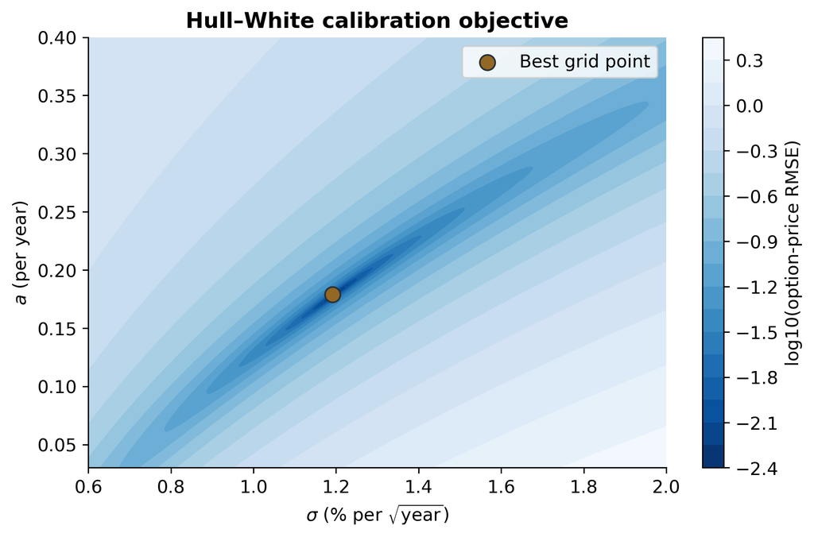

Figure 2: Option-pricing error across candidate Hull–White parameters

```python
fig, ax = plt.subplots(figsize=(8, 4.8))
contour = ax.contourf(
    100 * sigma_grid,
    a_grid,
    np.log10(error_surface + 1e-8),
    levels=25,
    cmap="Blues_r",
)
ax.scatter(100 * calibrated_sigma, calibrated_a, s=90, color=GOLD,
           edgecolor=INK, label="Best grid point", zorder=3)
ax.set(xlabel="$\sigma$ (% per $\sqrt{\mathrm{year}}$)",
       ylabel="$a$ (per year)",
       title="Hull–White calibration objective")
ax.legend()
fig.colorbar(contour, ax=ax, label="log10(option-price RMSE)")
plt.show()
```

**Show calculation**

```python
fitted_option_prices = np.array([
    zero_bond_call_price(expiry, maturity, strike,
                         calibrated_a, calibrated_sigma)
    for expiry, maturity, strike in zip(
        option_expiries, underlying_maturities, option_strikes
    )
])

option_fit = option_market.copy()
option_fit["model_price"] = fitted_option_prices
option_fit["pricing_error"] = fitted_option_prices - observed_option_prices
display(option_fit.round(6))
```

| Option expiry (years) | Bond maturity (years) | Strike per 100 | Synthetic option premium per 100 | Model premium per 100 | Pricing error per 100 |
| --- | --- | --- | --- | --- | --- |
| 0.5 | 5.5 | 80.514656 | 0.844722 | 0.838561 | -0.006161 |
| 1 | 6 | 80.280132 | 1.11236 | 1.110013 | -0.002348 |
| 1.5 | 6.5 | 80.060172 | 1.281444 | 1.273887 | -0.007558 |
| 2 | 7 | 79.932583 | 1.381698 | 1.380736 | -0.000962 |
| 3 | 8 | 79.620518 | 1.501708 | 1.495199 | -0.006508 |
| 4 | 9 | 79.328909 | 1.536209 | 1.533078 | -0.003131 |
| 5 | 10 | 79.049312 | 1.535476 | 1.528147 | -0.007329 |

**Show calculation**

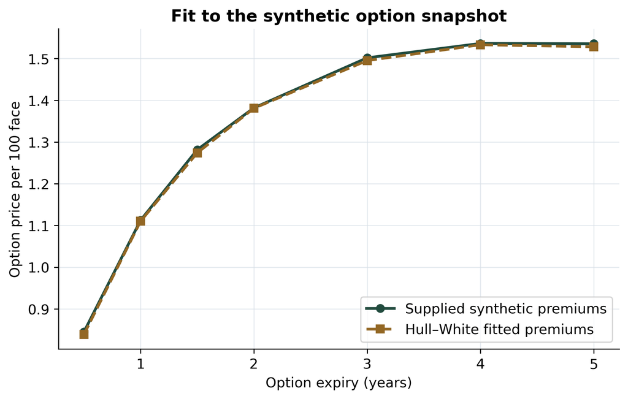

Figure 3: Observed artificial option premiums and calibrated Hull–White prices

```python
plt.plot(option_expiries, observed_option_prices, "o-", color=BLUE,
         label="Supplied synthetic premiums")
plt.plot(option_expiries, fitted_option_prices, "s--", color=GOLD,
         label="Hull–White fitted premiums")
plt.xlabel("Option expiry (years)")
plt.ylabel("Option price per 100 face")
plt.title("Fit to the synthetic option snapshot")
plt.legend()
plt.show()
```

## 6 Fit the time-dependent drift to today’s curve

Let $0=T_0<T_1<\cdots<T_N$ be the actual bootstrap dates. Use one unknown constant per interval:

$$\theta(t)=\theta_i\quad\text{for }T_{i-1}\leq t<T_i,\qquad i=1,\ldots,N.$$

The boundaries and the fitted values together define the full drift function. The final value continues after $T_N$. Here $N$ is the number of bootstrap targets, computed from the data; it is not a hard-coded choice.

For each fixed pair $(a,\sigma)$ and the chosen $r_0$, solve

$$P^{\mathrm{model}}(0,T_i; a,\sigma,\theta_1,\ldots,\theta_N)
=P^{\mathrm{boot}}(0,T_i),\qquad i=1,\ldots,N.$$

**How the fit works:** choose $\theta_1$ to match the first target. Keep it fixed, choose $\theta_2$ to match the second, and continue. Later intervals cannot affect an earlier payment, so this is a sequential solve. The Gaussian model makes each equation linear in the unknown drift constants when written in log-discount form. No derivatives of an interpolated curve are required.

The fitted $\theta(t)$ is a drift intercept: the rate’s conditional drift is $\theta(t)-a r_t$, not $\theta(t)$ alone. Changing $a$ or $\sigma$ changes the constants needed to match the same initial targets, which is why the option-calibration loop refits them for each candidate pair.

**Show calculation**

| Interval start (years) | Interval end (years) | Drift intercept theta (decimal rate/year) |
| --- | --- | --- |
| 0 | 1 | 0.007357 |
| 1 | 2 | 0.010826 |
| 2 | 3 | 0.00579 |
| 3 | 4 | 0.01211 |
| 4 | 5 | 0.006424 |
| 5 | 6 | 0.012218 |
| 6 | 7 | 0.007194 |
| 7 | 8 | 0.01013 |
| 8 | 9 | 0.009087 |
| 9 | 10 | 0.010408 |

```
Fitted intervals: 10; final value extends past year 10.
```

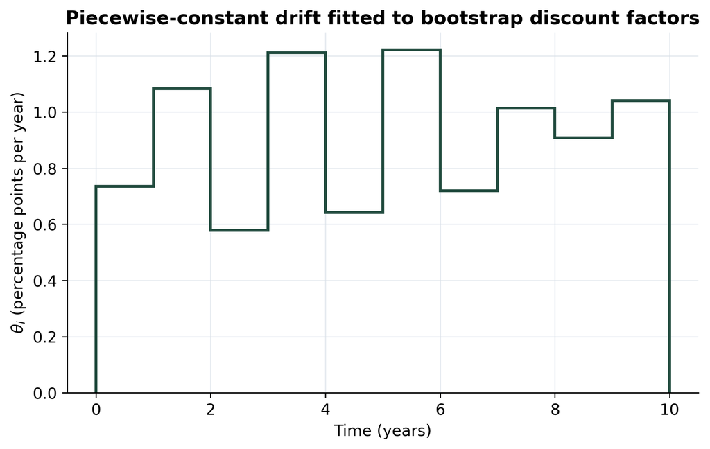

```python
theta_values = fitted_theta(calibrated_a, calibrated_sigma)
theta_table = pd.DataFrame({
    "Interval start (years)": interval_starts,
    "Interval end (years)": curve_times,
    "Drift intercept theta (decimal rate/year)": theta_values,
})
display(theta_table)
print(f"Fitted intervals: {len(theta_values)}; final value extends past year {curve_times[-1]:g}.")

plt.stairs(100 * theta_values, np.r_[0.0, curve_times], color=BLUE, linewidth=2)
plt.xlabel("Time (years)")
plt.ylabel(r"$\theta_i$ (percentage points per year)")
plt.title("Piecewise-constant drift fitted to bootstrap discount factors")
plt.show()
```

### 6.1 Verify that Hull–White reproduces today’s discount curve

Use the fitted model to calculate

$$P^{\mathrm{model}}(0,T_i)=A(0,T_i)e^{-B(0,T_i)r_0}$$

and compare it with $P^{\mathrm{boot}}(0,T_i)$ at each bootstrap maturity. These are **prices of one unit paid at maturity**, not the par coupon-bond price of 100. The differences below should be zero apart from numerical rounding. Between these nodes, the same fitted model supplies the discount curve.

**Show calculation**

```python
hw_discounts_today = discount_0(curve_times, calibrated_a, calibrated_sigma)
initial_fit = pd.DataFrame({
    "maturity": curve_times,
    "market_discount": bootstrapped_discounts,
    "hw_discount": hw_discounts_today,
    "difference": hw_discounts_today - bootstrapped_discounts,
})
display(initial_fit.round(10))
```

| Maturity (years) | Initial P(0,T) | Hull–White P(0,T) | Difference |
| --- | --- | --- | --- |
| 1 | 0.959969 | 0.959969 | 0 |
| 2 | 0.920097 | 0.920097 | 0 |
| 3 | 0.881528 | 0.881528 | 0 |
| 4 | 0.84371 | 0.84371 | 0 |
| 5 | 0.806752 | 0.806752 | 0 |
| 6 | 0.770665 | 0.770665 | 0 |
| 7 | 0.735457 | 0.735457 | 0 |
| 8 | 0.701877 | 0.701877 | 0 |
| 9 | 0.669306 | 0.669306 | 0 |
| 10 | 0.637732 | 0.637732 | 0 |

## 7 Generate future yield curves

Move to year 2. In a one-factor Hull–White model, the short rate $r_2$ is the single state variable. Hold the initial curve, $a$, and $\sigma$ fixed. For a simulated or selected $r_2$, calculate $B(2,T)$ and $A(2,T)$ at each future payment date, then obtain $P(2,T)=A(2,T)e^{-B(2,T)r_2}$. Convert each conditional bond price to its continuously compounded zero yield:

$$y(2,T)=-\frac{\log P(2,T)}{T-2}.$$

We show three possible states around the model’s central short-rate level. They are scenarios, not point forecasts.

**Show calculation**

```python
future_time = 2.0
future_maturities = np.linspace(2.25, 10.0, 80)
central_short_rate = float(mean_short_rate(
    0.0, future_time, r_0, calibrated_a, calibrated_sigma))

# Exact Gaussian short-rate transitions; no Euler approximation or forward derivatives.
simulation_times = np.linspace(0.0, future_time, 25)
simulated_rates = np.empty((len(simulation_times), 8))
simulated_rates[0] = r_0
rng = np.random.default_rng(411)
for k, (start, end) in enumerate(zip(simulation_times[:-1], simulation_times[1:])):
    conditional_mean = mean_short_rate(
        start, end, simulated_rates[k], calibrated_a, calibrated_sigma)
    conditional_std = calibrated_sigma * np.sqrt(
        -np.expm1(-2 * calibrated_a * (end - start)) / (2 * calibrated_a))
    simulated_rates[k + 1] = conditional_mean + conditional_std * rng.standard_normal(8)

short_rate_states = {
    "Low-rate state": central_short_rate - 0.015,
    "Central state": central_short_rate,
    "High-rate state": central_short_rate + 0.015,
}

future_curve_rows = []
for state_name, short_rate in short_rate_states.items():
    state_discounts = hw_discount_factor(
        future_time,
        future_maturities,
        short_rate,
        calibrated_a,
        calibrated_sigma,
    )
    state_yields = -np.log(state_discounts) / (future_maturities - future_time)

    future_curve_rows.append(pd.DataFrame({
        "state": state_name,
        "short_rate": short_rate,
        "maturity": future_maturities,
        "zero_rate": state_yields,
    }))

future_curves = pd.concat(future_curve_rows, ignore_index=True)
display(future_curves.groupby("state").head(3).reset_index(drop=True).round(5))
```

| Rate state | Short rate (%) | Maturity (years) | Continuous zero rate (%) |
| --- | --- | --- | --- |
| Low-rate state | 2.91 | 2.25 | 2.917 |
| Low-rate state | 2.91 | 2.3481 | 2.92 |
| Low-rate state | 2.91 | 2.4462 | 2.923 |
| Central state | 4.41 | 2.25 | 4.384 |
| Central state | 4.41 | 2.3481 | 4.374 |
| Central state | 4.41 | 2.4462 | 4.364 |
| High-rate state | 5.91 | 2.25 | 5.851 |
| High-rate state | 5.91 | 2.3481 | 5.829 |
| High-rate state | 5.91 | 2.4462 | 5.806 |

**Show calculation**

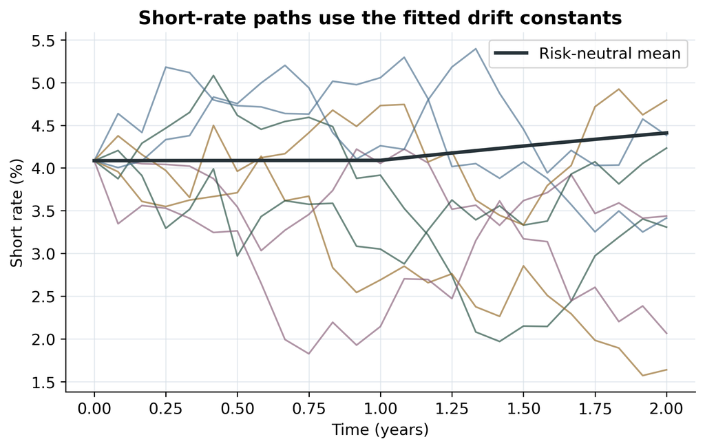

Figure 4: Exact Gaussian sample paths under the fitted piecewise-constant drift

```python
plt.plot(simulation_times, 100 * simulated_rates, alpha=0.65, linewidth=1.2)
plt.plot(simulation_times, 100 * mean_short_rate(
    0.0, simulation_times, r_0, calibrated_a, calibrated_sigma),
    color=INK, linewidth=2.5, label="Risk-neutral mean")
plt.xlabel("Time (years)")
plt.ylabel("Short rate (%)")
plt.title("Short-rate paths use the fitted drift constants")
plt.legend()
plt.show()
```

**Show calculation**

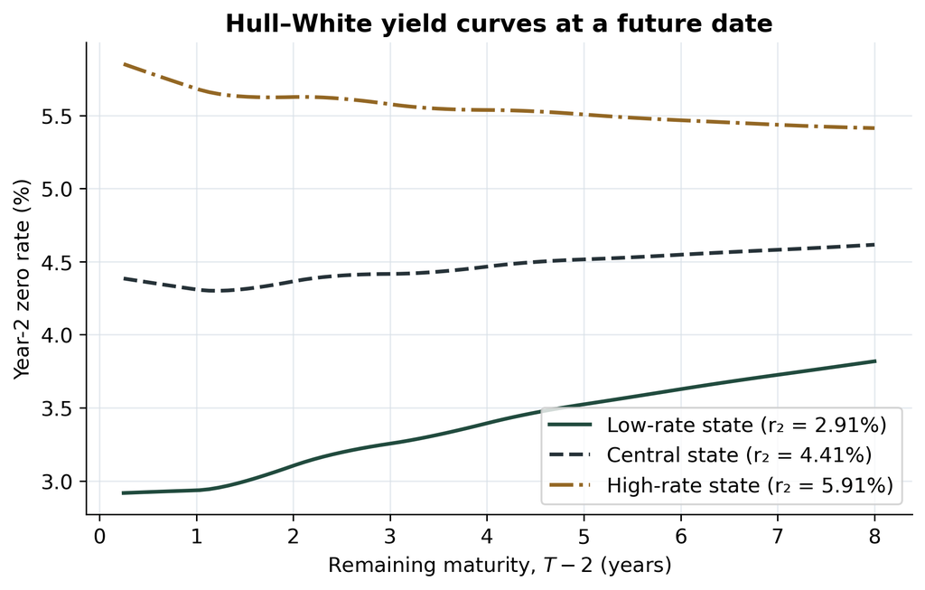

Figure 5: At year 2, one short-rate state determines a complete remaining yield curve

```python
styles = {
    "Low-rate state": (BLUE, "-"),
    "Central state": (INK, "--"),
    "High-rate state": (GOLD, "-."),
}

for state_name, group in future_curves.groupby("state", sort=False):
    color, line_style = styles[state_name]
    plt.plot(group["maturity"] - future_time, 100 * group["zero_rate"],
             color=color, linestyle=line_style, linewidth=2,
             label=f"{state_name} (r₂ = {100 * group['short_rate'].iloc[0]:.2f}%)")

plt.xlabel("Remaining maturity, $T-2$ (years)")
plt.ylabel("Year-2 zero rate (%)")
plt.title("Hull–White yield curves at a future date")
plt.legend()
plt.show()
```

Notice that one factor moves the whole curve in a structured way. Mean reversion causes the effect of today’s short-rate state to weaken at longer maturities because the zero-yield sensitivity is $B(t,T)/(T-t)$: $B(t,T)$ approaches $1/a$ while remaining maturity grows.

## 8 Use a future curve to price a bond

**Show calculation**

```python
def price_bond_at_time(valuation_time, payment_times, cash_flows,
                       short_rate, mean_reversion, volatility):
    """Price fixed cash flows at a future date using a Hull–White curve.

    Output is the value at `valuation_time`, not today's value.
    """
    payment_times = np.asarray(payment_times, dtype=float)
    cash_flows = np.asarray(cash_flows, dtype=float)

    if np.any(payment_times <= valuation_time):
        raise ValueError("Every payment must occur after the valuation time.")

    future_discounts = hw_discount_factor(
        valuation_time,
        payment_times,
        short_rate,
        mean_reversion,
        volatility,
    )
    return float(np.sum(cash_flows * future_discounts))


payment_times = np.arange(3.0, 11.0)
remaining_cash_flows = np.full(len(payment_times), 4.10)
remaining_cash_flows[-1] += 100.0

future_bond_values = []
for state_name, short_rate in short_rate_states.items():
    value = price_bond_at_time(
        future_time,
        payment_times,
        remaining_cash_flows,
        short_rate,
        calibrated_a,
        calibrated_sigma,
    )
    future_bond_values.append({
        "state": state_name,
        "short_rate_pct": 100 * short_rate,
        "bond_value_at_year_2": value,
    })

future_value_table = pd.DataFrame(future_bond_values)
display(future_value_table.round(4))
```

| Rate state | Short rate (%) | Year-2 bond value per 100 |
| --- | --- | --- |
| Low-rate state | 2.9105 | 101.7261 |
| Central state | 4.4105 | 96.0321 |
| High-rate state | 5.9105 | 90.6729 |

**Show calculation**

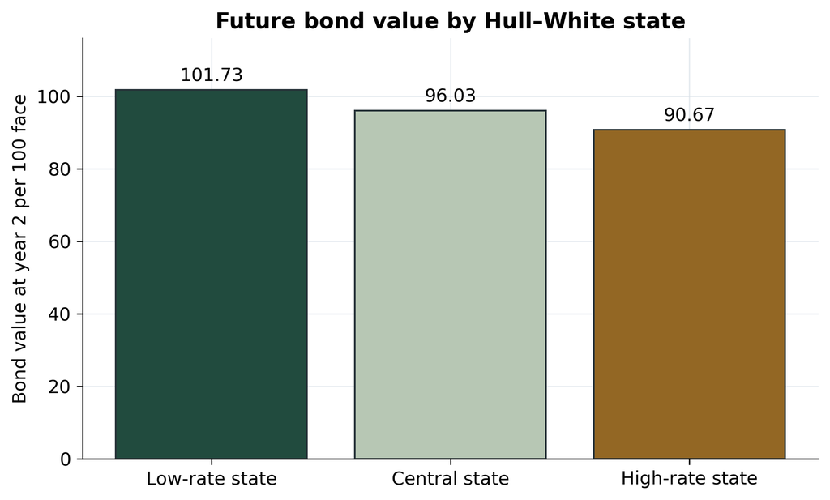

Figure 6: The same promised cash flows have different values in different year-2 rate states

```python
plot_table = future_value_table.sort_values("short_rate_pct")
bars = plt.bar(plot_table["state"], plot_table["bond_value_at_year_2"],
               color=[BLUE, LIGHT_BLUE, GOLD], edgecolor=INK)
plt.bar_label(bars, fmt="%.2f", padding=3)
plt.ylabel("Bond value at year 2 per 100 face")
plt.title("Future bond value by Hull–White state")
plt.ylim(0, 1.14 * plot_table["bond_value_at_year_2"].max())
plt.show()
```

This future valuation is where a short-rate model becomes useful. Today we do not observe $P(2,T)$; Hull–White generates it consistently for each possible $r_2$.

## 9 Plain-bond consistency at time 0

Finally, verify the lecture’s important claim: once Hull–White is calibrated to the observed curve, it does **not** create a different time-0 price for a vanilla bond. Both methods discount the same fixed cash flows with the same $P(0,T)$.

**Show calculation**

```python
vanilla_payment_times = np.arange(1.0, 11.0)
vanilla_cash_flows = np.full(10, 4.10)
vanilla_cash_flows[-1] += 100.0

# Method 1: discount directly with today's observed/bootstrapped curve.
direct_curve_price = float(np.sum(
    vanilla_cash_flows * discount_0(vanilla_payment_times, calibrated_a, calibrated_sigma)
))

# Method 2: use the calibrated Hull–White zero-coupon formula at t = 0.
hw_curve_price = float(np.sum(
    vanilla_cash_flows
    * hw_discount_factor(
        0.0,
        vanilla_payment_times,
        r_0,
        calibrated_a,
        calibrated_sigma,
    )
))

print(f"Direct observed-curve price: {direct_curve_price:.10f}")
print(f"Calibrated Hull–White price:  {hw_curve_price:.10f}")
print(f"Difference:                    {hw_curve_price - direct_curve_price:.12f}")
```

```
Direct observed-curve price: 96.2742663687
Calibrated Hull–White price:  96.2742663687
Difference:                    0.000000000000
```

## 10 Checks and interpretation

The workflow has three separate fits, each with a different purpose:

| Calibration object | Observable input | What is fitted | Why it matters |
| --- | --- | --- | --- |
| Today’s discount curve | Coupon-bond prices | $P(0,T)$ | Prices fixed cash flows today |
| Initial Hull–White term structure | Bootstrapped $P(0,T_i)$ | Interval constants $\theta_i$ | Matches every bootstrap target within one Gaussian model |
| Future dynamics | Interest-rate option premiums | $a,\sigma$ | Controls mean reversion and uncertainty |

**Show calculation**

```python
# The discounted conditional price must agree with the initial model price.
# (Integral of r, terminal r) is jointly Gaussian; include their covariance.
check_t, check_T = 1.25, 5.5
check_b = float(hw_B(check_t, check_T, calibrated_a))
check_mean_r = float(mean_short_rate(0.0, check_t, r_0, calibrated_a, calibrated_sigma))
check_mean_integral = (float(hw_B(0.0, check_t, calibrated_a)) * r_0
    + float(interval_weights(0.0, check_t, calibrated_a) @ theta_values))
check_var_r = calibrated_sigma**2 * -np.expm1(-2 * calibrated_a * check_t) / (2 * calibrated_a)
check_cov = calibrated_sigma**2 * (-np.expm1(-calibrated_a * check_t))**2 / (2 * calibrated_a**2)
check_var_integral = float(integrated_rate_variance(0.0, check_t, calibrated_a, calibrated_sigma))
check_A = float(hw_discount_factor(check_t, check_T, 0.0, calibrated_a, calibrated_sigma))
tower_price = check_A * np.exp(-check_mean_integral - check_b * check_mean_r
    + 0.5 * (check_var_integral + check_b**2 * check_var_r + 2 * check_b * check_cov))
tower_error = abs(tower_price - float(discount_0(check_T, calibrated_a, calibrated_sigma)))
candidate_fit_error = max(np.max(np.abs(discount_0(curve_times, a, sigma)
    - bootstrapped_discounts)) for a, sigma in [(0.03, 0.006), (0.40, 0.020)])
print(f"Largest initial-node fit error: {np.max(np.abs(hw_discounts_today-bootstrapped_discounts)):.3e}")
print(f"Candidate-parameter node fit error: {candidate_fit_error:.3e}")
print(f"Discounted conditional-price consistency error: {tower_error:.3e}")

checks = {
    "Each candidate refits the bootstrap targets": candidate_fit_error < 1e-12,
    "Conditional and initial pricing agree at fractional dates": tower_error < 1e-12,
    "Immediate payment has unit discount factor": abs(float(hw_discount_factor(
        check_t, check_t, check_mean_r, calibrated_a, calibrated_sigma)) - 1.0) < 1e-12,
    "Bootstrap reprices input bonds": np.max(np.abs(repriced_bonds - clean_prices)) < 1e-10,
    "Discount factors are positive": np.all(bootstrapped_discounts > 0),
    "Discount factors decrease with maturity": np.all(np.diff(bootstrapped_discounts) < 0),
    "Hull–White matches all bootstrap targets": np.max(
        np.abs(hw_discounts_today - bootstrapped_discounts)
    ) < 1e-10,
    "Two vanilla-bond pricing methods agree": abs(
        hw_curve_price - direct_curve_price
    ) < 1e-10,
}

display(pd.Series(checks, name="passed").to_frame())
assert all(checks.values())
```

```
Largest initial-node fit error: 1.110e-16
Candidate-parameter node fit error: 1.110e-16
Discounted conditional-price consistency error: 0.000e+00
```

| Check | passed |
| --- | --- |
| Each candidate refits the bootstrap targets | True |
| Conditional and initial pricing agree at fractional dates | True |
| Immediate payment has unit discount factor | True |
| Bootstrap reprices input bonds | True |
| Discount factors are positive | True |
| Discount factors decrease with maturity | True |
| Hull–White matches all bootstrap targets | True |
| Two vanilla-bond pricing methods agree | True |

## 11 Takeaways

**TipSeparate calibration from a scenario**

First compare observed and interpolated nodes. Then inspect the option-fit error: an exact fit to today’s curve does not guarantee an exact fit to every option. Finally change only the future short-rate state. Today’s curve stays unchanged, but the future bond value changes. Explain why the year-2 value excludes coupons already paid and is not a two-year holding-period total return.

**Market handoff:** the embedded Treasury observations are a reproducible dated snapshot, not today’s curve. Replace the entire dated node table together, retain the observed/interpolated labels, and rerun every check. Keep the supplied synthetic option prices if a permitted option dataset is unavailable; do not label recovered parameters as empirically calibrated market dynamics.

- Market bond prices can be converted into discount factors by bootstrapping.
- Hull–White does not fit a whole curve using only two constants. The function $\theta_i$ values fit today’s bootstrap targets; $a$ and $\sigma$ describe future dynamics.
- Option prices provide information about those dynamics that vanilla bond prices do not.
- At a future date, each one-factor Hull–White short-rate state produces a complete yield curve and a value for the remaining cash flows.
- A vanilla bond has the same time-0 value under calibrated Hull–White and direct curve discounting. The model earns its keep when future rates affect valuation or cash flows.

**NoteSimplifications**

Real desks use multiple instrument types, day-count conventions, accrued interest, bid/ask spreads, smooth curve interpolation, and robust numerical optimizers. The demo deliberately removes those layers so the economic logic stays visible.

## 12 Interactive explorer

Change the **Treasury par-yield input curve**, mean reversion $a$, or volatility $\sigma$. Every change rebuilds the annual par instruments, bootstraps discount targets, refits all $\theta_i$, and updates the model-implied future short-rate distribution. The baseline is the dated input snapshot and the option-calibrated parameters above. Manual parameter changes here are scenarios, not a new option calibration.

The initial state is always reset consistently to $r_0=-\log P^{\mathrm{boot}}(0,T_1)/T_1$. A curve-only change holds $a$ and $\sigma$ fixed: the future mean changes, but the Gaussian short-rate variance does not. Changing $a$, $\sigma$, or the horizon changes

$$\operatorname{Var}^{\mathbb Q}(r_h\mid r_0)=\frac{\sigma^2}{2a}(1-e^{-2ah}).$$

Level moves every observed par node equally. Slope tilts the 1Y and 10Y endpoints in opposite directions. The middle hump leaves those endpoints fixed. Missing annual nodes are interpolated before bootstrapping.

━━ Current scenario ┄┄ Original baseline Shading: current 95% short-rate band

[output not shown]